# Computational Thinking in the Humanities

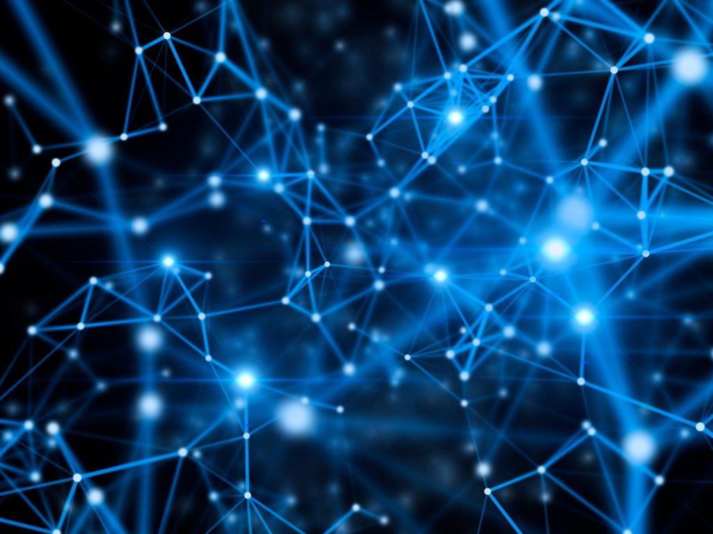

The workshop **Computational Thinking in the Humanities** is a 3-hour online workshop featuring two plenary talks, lightning presentations, as well as a panel discussion. The workshop is co-organized by the [**Australian Text Analytics Platform (ATAP)**](https://www.atap.edu.au/), [**FIN-CLARIAH**](https://www.kielipankki.fi/organization/fin-clariah/) and its UEF representatives, and the [**Australian Digital Observatory**](https://www.digitalobservatory.net.au/).

The workshop has received financial supported from the [**Digital Cultures and Societies Hub**](https://hass.uq.edu.au/Digital-Cultures-and-Societies) at the [University of Queensland](https://uq.edu.au/).

The workshop takes place

**Thursday, Sep. 1, 2022**, 5-8pm Queensland, 10am-1pm Finland, 8-11am UK.

**Zoom link**: https://uqz.zoom.us/j/86311263161

# Event Description

Computers and software are now inescapable in our daily lives - while much of our research might now be enabled or mediated by these computers, that doesn’t mean that our research practices have fundamentally changed - a digital library is still recognisably a library.

- What does computational thinking mean for the humanities?
- How can the humanities embrace computing and computational approaches on their own terms, and avoid simply scavenging and repurposing approaches developed within other fields?
- How do we resist having our “problems” “solved” for us?
- What are the methodological and epistemological foundations of a field that is both computational and of the humanities - does computation actually change the nature of what we do?

This international workshop will bring together speakers to address this topic, drawing on perspectives from several fields. We hope that this event will prompt reflection, introduce new ideas, spark discussions and plant the seeds for future collaborations.

# Program

**Part I (90 min)**

- Opening and Introductions
- Plenary 1: [Krista Lagus](https://researchportal.helsinki.fi/en/persons/krista-lagus): Bridging the impossible - How to avoid bringing technodystopia to the social sciences
- Plenary 2: [Barbara McGillivray](https://www.turing.ac.uk/people/researchers/barbara-mcgillivray): Computational approaches and the Humanities: what might await us?

Break

**Part 2 (80 mins)**

- Lightning talks
  - [Marissa Takahashi](https://www.qut.edu.au/about/our-people/academic-profiles/marissa.takahashi) (QUT, Project Manager of the [Australian Digital Observatory (ADO)](https://www.digitalobservatory.net.au/))
  - [Martin Schweinberger](http://www.martinschweinberger.de) (UQ, co-director of [LADAL](https://ladal.edu.au/))
  - [Eetu Mäkelä](https://blogs.helsinki.fi/jiemakel/) (technical director of [FIN-CLARIAH](https://www.kielipankki.fi/organization/fin-clariah/))
  - [Steven Coats](https://cc.oulu.fi/~scoats/) (University of Oulu)
- Panel discussion (20 min)

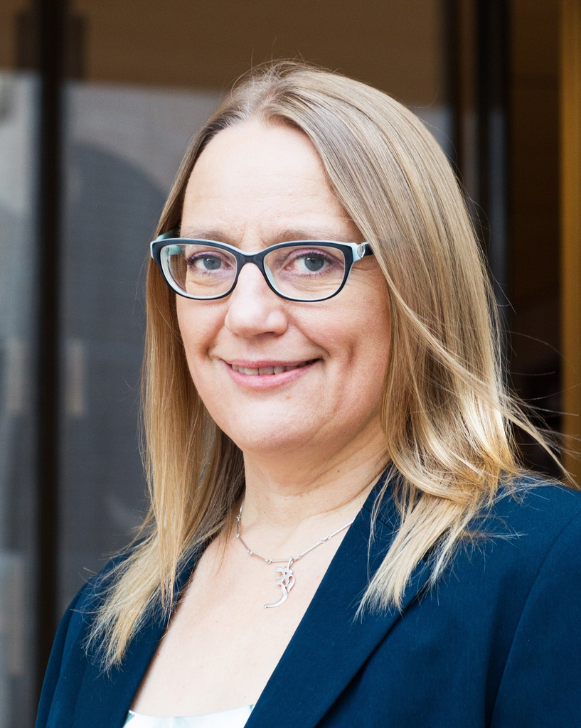

## Krista Lagus

Krista is full professor at the University of Helsinki in the [Centre for Social Data Science, CSDS](https://www.helsinki.fi/en/networks/centre-social-data-science). There, she applies quantitative and qualitative data analysis methods in order to understand various individual and social practices that affect the well-being of individuals. Recent topics of interest include loneliness, peer support, mindfulness practices and life-philosophical lecturing.

## Barbara McGillivray

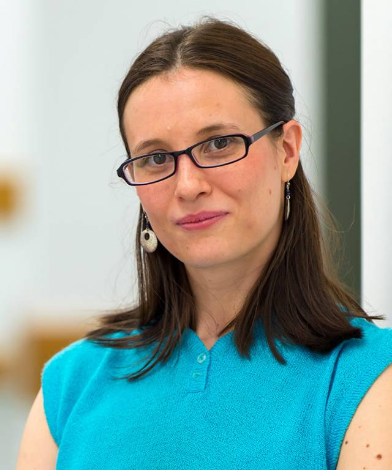

Barbara is lecturer in Digital Humanities and Cultural Computation at the Department of Digital Humanities of King’s College London and a Turing Research Fellow at The Alan Turing Institute. She is also Editor in Chief of the *Journal of Open Humanities Data*. Before going back to academia, Barbara was language technologist in the Dictionary division of Oxford University Press and data scientist in the Open Research Group of Springer Nature.

Barbara has always been passionate about how the sciences and the humanities can meet. Her most recent book is *Applying Language Technology in Humanities Research. Design, Application, and the Underlying Logic*, co-authored with Gábor Mihály Tóth and published by Palgrave Macmillan in 2020.

Back to top

[Back to HOME](https://slcladal.github.io/index.html)